# Data Clean and Statistics Excercise

Patricia Pinter

2024-06-18

## head data of datasets

```r
head(patient_info)
```

```
##   Participant_ID    Sex Age Smoking_status     BMI Disease
## 1        1003300   Male  62       Previous 33.7597       2
## 2        1004025   Male  60       Previous 28.1173       1
## 3        1005551   Male  69       Previous 26.4159       2
## 4        1005594   Male  64       Previous 24.7550       1
## 5        1005624   Male  64       Previous 35.0773       2
## 6        1008540 Female  64       Previous 21.6764       2
```

```r
head(hospital_visit)
```

```
##   Participant_ID  VisitDate
## 1        1003300   1/7/2022
## 2        1003300 27/10/2021
## 3        1004025 19/05/2010
## 4        1005551 25/08/2021
## 5        1005551 29/06/2021
## 6        1005594 27/01/2020
```

```r
# Convert NULLs to NAs if any
patient_info <- patient_info %>%
  mutate(across(everything(), ~replace(., is.null(.), NA)))

# Calculate median BMI for each gender
median_bmi_male <- median(patient_info %>% filter(Sex == 'Male') %>% pull(BMI), na.rm = TRUE)
median_bmi_female <- median(patient_info %>% filter(Sex == 'Female') %>% pull(BMI), na.rm = TRUE)

# Replace missing BMI values with the median for the corresponding gender
patient_info <- patient_info %>%
  mutate(BMI = ifelse(is.na(BMI) & Sex == 'Male', median_bmi_male, BMI),
         BMI = ifelse(is.na(BMI) & Sex == 'Female', median_bmi_female, BMI))
```

```r
# Remove duplicates based on Participant_ID
patient_info <- patient_info %>%
  filter(!duplicated(Participant_ID))

# Perform sanity checks on patient information
patient_info <- patient_info %>%
  filter(is.numeric(Participant_ID),
         nchar(as.character(Participant_ID)) == 7,
         Sex %in% c('Male', 'Female'),
         Age >= 40 & Age <= 120,
         BMI >= 15 & BMI <= 60,
         Smoking_status %in% c('Never', 'Previous', 'Current', 'Prefer not to answer'),
         Disease %in% c(1, 2))


# Convert VisitDate to Date type with correct format
hospital_visit$VisitDate <- as.Date(hospital_visit$VisitDate, format="%d/%m/%Y")

# Remove duplicates based on Participant_ID and VisitDate
hospital_visit <- hospital_visit %>%
  filter(!duplicated(paste(Participant_ID, VisitDate)))

# Perform sanity checks on hospital visit data
hospital_visit <- hospital_visit %>%
  filter(is.numeric(Participant_ID),
         nchar(as.character(Participant_ID)) == 7,
          as.Date(VisitDate, format="%d/%m/%Y") >= as.Date("01/01/1950", format="%d/%m/%Y") &
         as.Date(VisitDate, format="%d/%m/%Y") <= as.Date("31/12/2023", format="%d/%m/%Y"))



head(hospital_visit)
```

```
##   Participant_ID  VisitDate
## 1        1003300 2022-07-01
## 2        1003300 2021-10-27
## 3        1004025 2010-05-19
## 4        1005551 2021-08-25
## 5        1005551 2021-06-29
## 6        1005594 2020-01-27
```

```r
# Calculate the number of visits each patient made since 1/1/2020. If the VisitDate is missing, it indicates no visits during this period.


# Filter visits since 1/1/2020
hospital_visit_2020 <- hospital_visit %>% filter(VisitDate >= as.Date("1/1/2020"))

# Calculate the number of visits per participant since 1/1/2020
num_visits <- hospital_visit_2020 %>%
  group_by(Participant_ID) %>%
  summarise(Number_of_visits_since_2020 = n())

# Merge this information with patient information
patient_info <- left_join(patient_info, num_visits, by = "Participant_ID")

# Replace NA values in Number_of_visits_since_2020 with 0
patient_info <- patient_info %>% replace_na(list(Number_of_visits_since_2020 = 0))
```

```r
# Create a summary table and/or chart showing the number of visits for each month (irrespective of the year).
monthly_visits <- hospital_visit %>%
  filter(!is.na(VisitDate)) %>%
  mutate(Month = floor_date(VisitDate, "month")) %>%
  group_by(Month) %>%
  summarise(Number_of_visits = n())

# Print the summary table
print(monthly_visits)
```

```
## # A tibble: 278 × 2
##    Month      Number_of_visits
##    <date>                <int>
##  1 1996-11-01                1
##  2 1997-04-01                1
##  3 1997-11-01                1
##  4 1998-03-01                1
##  5 1998-04-01                1
##  6 1998-06-01                1
##  7 1998-08-01                3
##  8 1998-09-01                1
##  9 1998-12-01                1
## 10 1999-02-01                1
## # ℹ 268 more rows
```

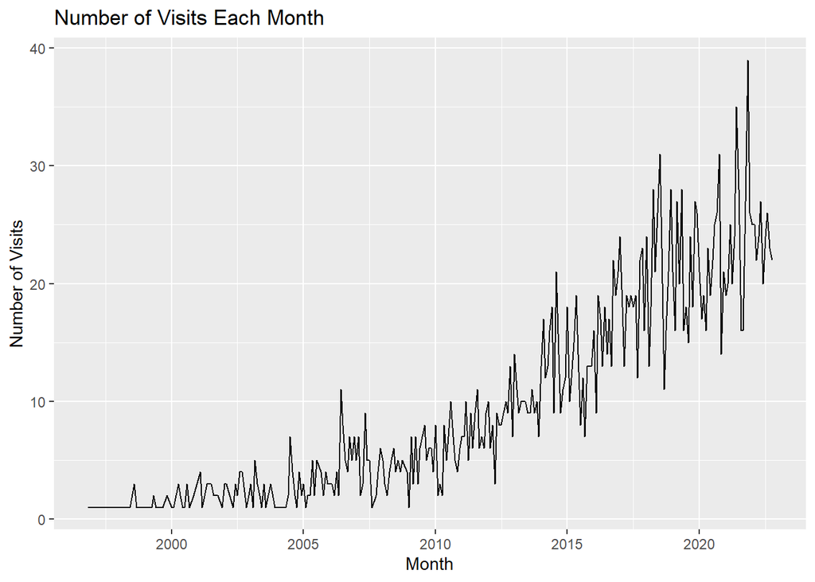

```r
# Plotting the monthly visits
ggplot(monthly_visits, aes(x = Month, y = Number_of_visits)) +
  geom_line() +
  labs(title = "Number of Visits Each Month", x = "Month", y = "Number of Visits")
```

```r
# Define age groups
age_bins <- c(40, 50, 60, 70, Inf)
age_labels <- c('40-49', '50-59', '60-69', '70+')

# Add age group column
patient_info <- patient_info %>%
  mutate(Age_group = cut(Age, breaks = age_bins, labels = age_labels, right = FALSE))
```

## Final Patient Information Table

```r
# Output the final patient_info table
knitr::kable(patient_info)
```

| Participant_ID | Sex | Age | Smoking_status | BMI | Disease | Number_of_visits_since_2020 | Age_group |
| --- | --- | --- | --- | --- | --- | --- | --- |
| 1003300 | Male | 62 | Previous | 33.75970 | 2 | 2 | 60-69 |
| 1004025 | Male | 60 | Previous | 28.11730 | 1 | 1 | 60-69 |
| 1005551 | Male | 69 | Previous | 26.41590 | 2 | 2 | 60-69 |
| 1005594 | Male | 64 | Previous | 24.75500 | 1 | 1 | 60-69 |
| 1005624 | Male | 64 | Previous | 35.07730 | 2 | 2 | 60-69 |
| 1008540 | Female | 64 | Previous | 21.67640 | 2 | 1 | 60-69 |
| 1008931 | Male | 62 | Previous | 26.95290 | 2 | 2 | 60-69 |
| 1010012 | Male | 66 | Never | 33.81260 | 2 | 1 | 60-69 |
| 1010841 | Male | 58 | Previous | 30.08260 | 1 | 2 | 50-59 |
| 1015236 | Male | 63 | Previous | 23.88040 | 2 | 1 | 60-69 |
| 1022720 | Male | 40 | Never | 37.55210 | 2 | 1 | 40-49 |
| 1030927 | Male | 69 | Previous | 24.95250 | 2 | 1 | 60-69 |
| 1031255 | Male | 63 | Previous | 26.37280 | 2 | 1 | 60-69 |
| 1033353 | Female | 67 | Previous | 24.17950 | 2 | 3 | 60-69 |
| 1038476 | Male | 66 | Never | 27.56520 | 2 | 1 | 60-69 |
| 1039893 | Female | 61 | Never | 23.76450 | 1 | 1 | 60-69 |
| 1041231 | Male | 65 | Never | 27.85330 | 1 | 0 | 60-69 |
| 1043442 | Male | 67 | Previous | 27.96620 | 2 | 1 | 60-69 |
| 1044192 | Female | 44 | Never | 28.96340 | 1 | 1 | 40-49 |
| 1046601 | Male | 69 | Never | 27.12800 | 2 | 1 | 60-69 |
| 1054693 | Male | 55 | Never | 31.94260 | 2 | 1 | 50-59 |
| 1055009 | Male | 66 | Previous | 31.70610 | 1 | 1 | 60-69 |
| 1065297 | Male | 52 | Previous | 39.24290 | 2 | 1 | 50-59 |
| 1065453 | Male | 69 | Previous | 29.06570 | 1 | 1 | 60-69 |
| 1068968 | Male | 69 | Previous | 32.63310 | 2 | 4 | 60-69 |
| 1073595 | Male | 69 | Current | 34.18700 | 2 | 1 | 60-69 |
| 1076563 | Male | 62 | Never | 27.52180 | 2 | 1 | 60-69 |
| 1078461 | Male | 63 | Never | 38.86420 | 2 | 1 | 60-69 |
| 1087236 | Male | 69 | Previous | 28.49510 | 2 | 1 | 60-69 |
| 1089638 | Male | 60 | Current | 21.55540 | 2 | 1 | 60-69 |

[output cut: 2180 more lines]

## Merge the two files to include the columns: Patient_ID, Sex, Age, BMI, Smoking_status, Number_of_visits, Disease and age group

```r
# Perform the merge of table patient_info and hospital_visit based on Participant_ID
merged_table <- left_join(patient_info, hospital_visit, by = "Participant_ID")

# Check the merged dataset
head(merged_table)
```

```
##   Participant_ID  Sex Age Smoking_status     BMI Disease
## 1        1003300 Male  62       Previous 33.7597       2
## 2        1003300 Male  62       Previous 33.7597       2
## 3        1004025 Male  60       Previous 28.1173       1
## 4        1005551 Male  69       Previous 26.4159       2
## 5        1005551 Male  69       Previous 26.4159       2
## 6        1005594 Male  64       Previous 24.7550       1
##   Number_of_visits_since_2020 Age_group  VisitDate
## 1                           2     60-69 2022-07-01
## 2                           2     60-69 2021-10-27
## 3                           1     60-69 2010-05-19
## 4                           2     60-69 2021-08-25
## 5                           2     60-69 2021-06-29
## 6                           1     60-69 2020-01-27
```

## Statistic tasks

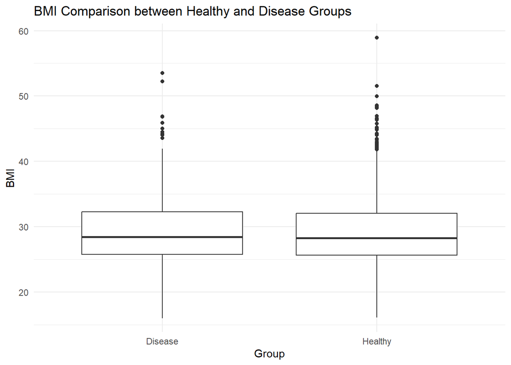

```r
# 1. Compare the BMI between the healthy and control groups using a box or violin plot.

# Box plot creation
ggplot(merged_table, aes(x = factor(Disease, levels = c(1, 2), labels = c('Disease', 'Healthy')), y = BMI)) +
  geom_boxplot() +
  labs(title = 'BMI Comparison between Healthy and Disease Groups', x = 'Group', y = 'BMI') +
  theme_minimal()
```

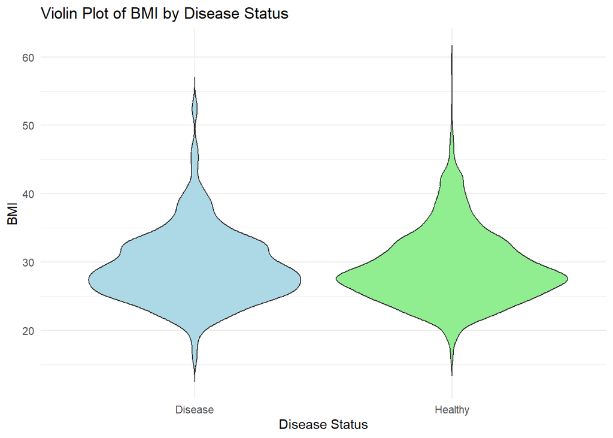

```r
# Violin plot creation
ggplot(merged_table, aes(x = factor(Disease, levels = c(1, 2),labels = c('Disease', 'Healthy')), y = BMI, fill = factor(Disease))) +
  geom_violin(trim = FALSE) +
  scale_fill_manual(values = c("lightblue", "lightgreen"), labels = c("Healthy", "Disease")) +
  labs(title = "Violin Plot of BMI by Disease Status", x = "Disease Status", y = "BMI") +
  theme_minimal() +
  theme(legend.position = "none")
```

Box Plot Interpretation:

The thick line inside the box represents the median BMI. Compare the median BMI between the healthy and disease groups.It seems to be on the same level for both, healthy and disease group. This suggests that there are no individuals in the disease group or healthy group that tend to have higher BMI values.

The box represents the Interquartile Range (IQR) (25th to 75th percentile). The box of the disease group appears a little bit wider on top than the one of healthy group. This indicates more variability in BMI among individuals of disease group.

The lines extending from the box (whiskers) represent the range of the data within 1.5 times the IQR. Points outside this range are potential outliers. These are individual BMI values that are significantly higher or lower than the rest of the data. There are more outliers in healthy group than in disease group.

Violin Plot Interpretation:

The shape of the violin plot of disease group appears a bit wider on top and bottom which shows a wider density and higher/lower BMIs of people in disease group than for people in healthy group. This could be a sign of more too lightweighted and overweighted people overall in disease group.

Summarized: Based on those visualizations it cannot be clearly said if the BMI has a relation to the health status of a person. There is only a vague tendency based on the variability of BMI among both groups.

```r
# 2. Examine if the proportion of smoking status differs between the healthy and control groups.

# Create a contingency table that summarizes the counts of smoking statuses for each group (healthy and disease).
smoking_table <- patient_info %>%
  filter(Disease %in% c(1, 2)) %>%
  count(Disease, Smoking_status) %>%
  spread(Smoking_status, n, fill = 0)

# Print the contingency table
print(smoking_table)
```

```
##   Disease Current Never Prefer not to answer Previous
## 1       1      92   214                    5      254
## 2       2     258   635                    4      748
```

```r
# Convert to matrix format for chi-squared test
smoking_matrix <- as.matrix(smoking_table[, -1]) # Remove Disease column for the test

# Perform the chi-squared test
chi_squared_test <- chisq.test(smoking_matrix)
# Print the results
print(chi_squared_test)
```

```
##
##  Pearson's Chi-squared test
##
## data:  smoking_matrix
## X-squared = 4.4313, df = 3, p-value = 0.2185
```

Interpretation: To interpret the results, we need to check the p-value from the test to determine if there is a significant difference in the proportion of smoking statuses between the healthy and disease groups. As the p value of this test is p-value = 0.2185, it is greater than 0.05. This suggests that there is no significant difference in the proportion of smoking statuses between the groups.

```r
# 3. Analyze the relationship between smoking status and the number of hospital visits, separately for the disease and healthy groups, and for the overall population.

# ANOVA for overall population
anova_overall <- aov(Number_of_visits_since_2020 ~ Smoking_status, data = merged_table)
summary(anova_overall)
```

```
##                  Df Sum Sq Mean Sq F value Pr(>F)
## Smoking_status    3      7   2.490   0.547   0.65
## Residuals      2874  13092   4.555
```

```r
# ANOVA for disease group
anova_disease <- aov(Number_of_visits_since_2020 ~ Smoking_status, data = merged_table %>% filter(Disease == 1))
summary(anova_disease)
```

```
##                 Df Sum Sq Mean Sq F value   Pr(>F)
## Smoking_status   3   50.2  16.727   7.607 5.16e-05 ***
## Residuals      734 1613.9   2.199
## ---
## Signif. codes:  0 '***' 0.001 '**' 0.01 '*' 0.05 '.' 0.1 ' ' 1
```

```r
# ANOVA for healthy group
anova_healthy <- aov(Number_of_visits_since_2020 ~ Smoking_status, data = merged_table %>% filter(Disease == 2))
summary(anova_healthy)
```

```
##                  Df Sum Sq Mean Sq F value Pr(>F)
## Smoking_status    3      6   1.855   0.347  0.791
## Residuals      2136  11410   5.342
```

Interpretation: side note: Pr(>F) = The p-value associated with the F-statistic The p-value from the ANOVA (Analysis of Variance) test for overall population is 0.65, which is greater than 0.05. This indicates that there is no statistically significant difference in the number of visits among different smoking statuses for the overall population.

The p-value from the ANOVA test for disease group is 5.16e-05, which is less than 0.05. This indicates that there is a statistically significant difference in the number of visits among different smoking statuses for the disease group.

The p-value from the ANOVA test for healthy group is 0.791, which is greater than 0.05. This indicates that there is no statistically significant difference in the number of visits among different smoking statuses for the healthy group.

Conclusion: The significant result in the disease group suggests that smoking status affects the number of hospital visits for patients with the disease, but not for the overall population or the healthy group.

```r
# 4. Determine if the number of visits is higher in the disease group compared to the healthy group.

# Perform a t-test to compare the number of visits between the disease and healthy groups
t_test_result <- t.test(Number_of_visits_since_2020 ~ Disease, data = merged_table)

# Output the result
print(t_test_result)
```

```
##
##  Welch Two Sample t-test
##
## data:  Number_of_visits_since_2020 by Disease
## t = -2.5455, df = 1975.8, p-value = 0.01099
## alternative hypothesis: true difference in means between group 1 and group 2 is not equal to 0
## 95 percent confidence interval:
##  -0.33584548 -0.04354819
## sample estimates:
## mean in group 1 mean in group 2
##        1.756098        1.945794
```

Interpretation: The average (mean) number of visits since 2020 is 1.76 for the disease group and 1.95 for the healthy group.

The t-test result (p-value = 0.01099) indicates a statistically significant difference between the two groups as it is less than 0.05.

The negative t-value of t = -2.5455 and confidence interval of 95 percent confidence interval: -0.33584548 , -0.04354819 suggest that the disease group has fewer visits on average compared to the healthy group.

In summary, the data suggests that patients in the disease group have, on average, significantly fewer hospital visits since 2020 compared to patients in the healthy group. This difference is statistically significant with a p-value of 0.01099.

```r
# 5. Calculate the disease prevalence (number of sick  / total number population) across different age groups in our dataset, and test if the prevalence is different across the group

# Calculate disease prevalence by age group
prevalence <- merged_table %>%
  group_by(Age_group) %>%
  summarise(Prevalence = mean(Disease == 1))

print(prevalence)
```

```
## # A tibble: 4 × 2
##   Age_group Prevalence
##   <fct>          <dbl>
## 1 40-49          0.292
## 2 50-59          0.218
## 3 60-69          0.265
## 4 70+            0.265
```

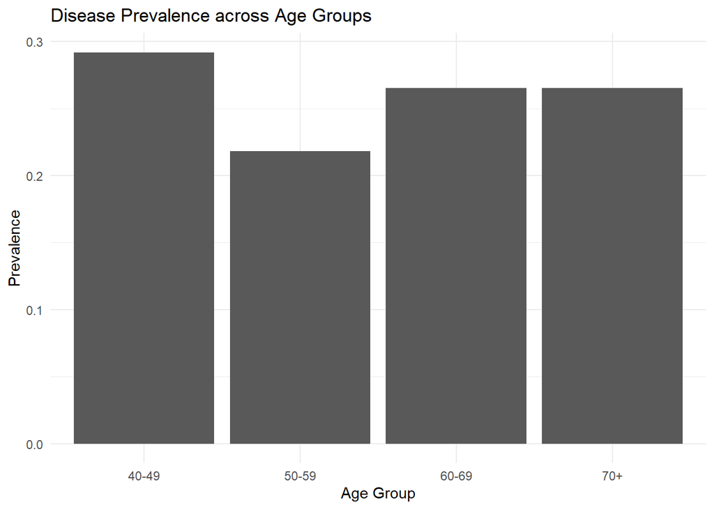

```r
# Plot disease prevalence across age groups
ggplot(prevalence, aes(x = Age_group, y = Prevalence)) +
  geom_bar(stat = "identity") +
  labs(title = 'Disease Prevalence across Age Groups', x = 'Age Group', y = 'Prevalence') +
  theme_minimal()
```

```r
# Test if prevalence is different across age groups
# Create a contingency table for disease status and age group
contingency_table_age <- table(merged_table$Age_group, merged_table$Disease)

print(contingency_table_age)
```

```
##
##            1    2
##   40-49   54  131
##   50-59  142  509
##   60-69  529 1464
##   70+     13   36
```

```r
# Perform a Chi-square test of independence
chi_square_test_age <- chisq.test(contingency_table_age)
chi_square_test_age
```

```
##
##  Pearson's Chi-squared test
##
## data:  contingency_table_age
## X-squared = 7.0962, df = 3, p-value = 0.06889
```

The p-value (0.06889) is slightly above the typical significance level of 0.05. This means that we do not have strong evidence to reject the null hypothesis that the disease prevalence is the same across all age groups. However, the p-value is close to 0.05, suggesting that there might be a trend towards a significant difference, and further investigation with a larger sample size might be warranted.